# STAT2401 Analysis of Experiments

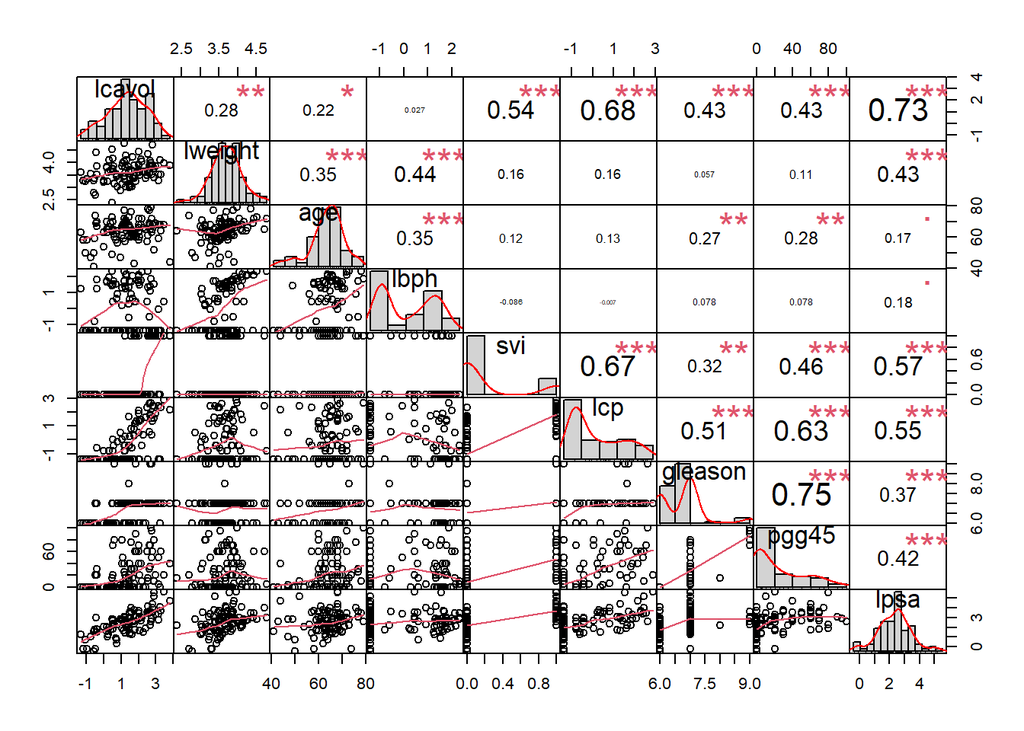

```r
# a more informatic graph
library("PerformanceAnalytics")
chart.Correlation(Prostate[, 2:10], histogram = TRUE, pch = 19)
```

We can also create the scatterplot matrix using *ggplot2* and *GGally* R packages.

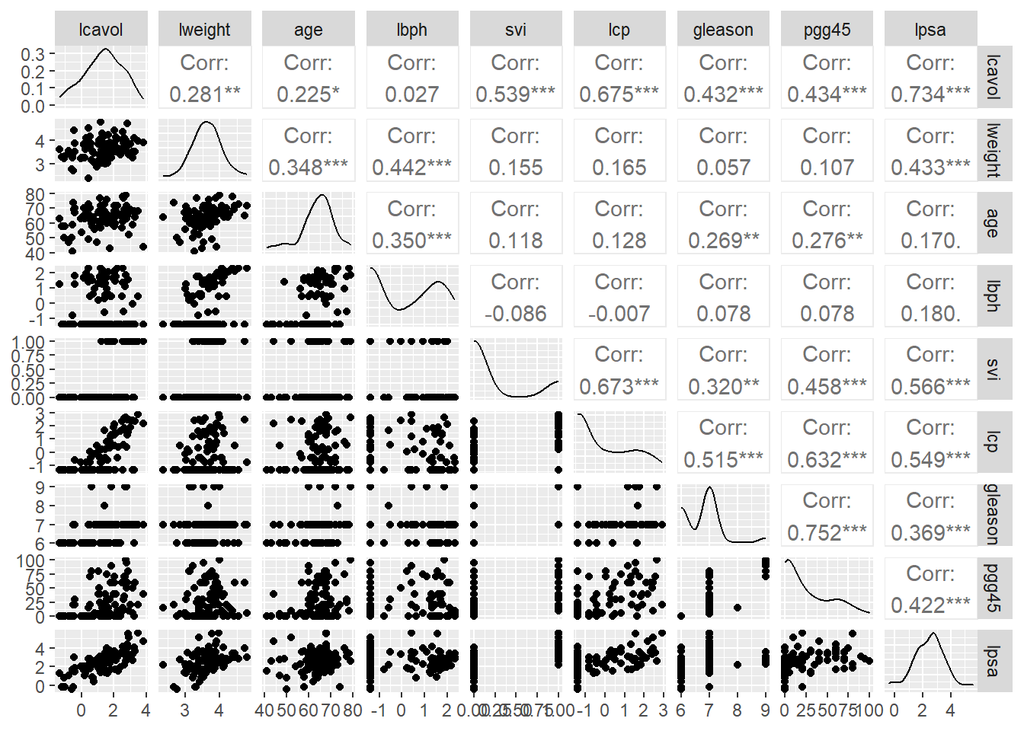

```r
library(dplyr)
library(ggplot2)
library(GGally)
ggpairs(Prostate, columns = 2:10)
```

3. Use correlation analysis to investigate the relationships among *lpsa* and the predictors or explanatory variables.

One can check from the above plots.

To present a correlation matrix:

```r
cor(Prostate[, 2:10])  ##
```

```
           lcavol    lweight       age         lbph         svi          lcp
lcavol  1.0000000 0.28052138 0.2249999  0.027349703  0.53884500  0.675310484
lweight 0.2805214 1.00000000 0.3479691  0.442264399  0.15538490  0.164537142
age     0.2249999 0.34796911 1.0000000  0.350185896  0.11765804  0.127667752
lbph    0.0273497 0.44226440 0.3501859  1.000000000 -0.08584324 -0.006999431
svi     0.5388450 0.15538490 0.1176580 -0.085843238  1.00000000  0.673111185
lcp     0.6753105 0.16453714 0.1276678 -0.006999431  0.67311118  1.000000000
gleason 0.4324171 0.05688209 0.2688916  0.077820447  0.32041222  0.514830063
pgg45   0.4336522 0.10735379 0.2761124  0.078460018  0.45764762  0.631528246
lpsa    0.7344603 0.43331938 0.1695928  0.179809404  0.56621822  0.548813175
           gleason      pgg45      lpsa
lcavol  0.43241706 0.43365225 0.7344603
lweight 0.05688209 0.10735379 0.4333194
age     0.26889160 0.27611245 0.1695928
lbph    0.07782045 0.07846002 0.1798094
svi     0.32041222 0.45764762 0.5662182
lcp     0.51483006 0.63152825 0.5488132
gleason 1.00000000 0.75190451 0.3689868
pgg45   0.75190451 1.00000000 0.4223159
lpsa    0.36898681 0.42231586 1.0000000
```

```
- Identify 3 predictors with the highest correlations (in magnitude) to the response.
```

The predictors are :lcavol (0.73); svi (0.57) and lcp (0.55)

```
- Identify 3 predictors with the lowest correlations (in magnitude) to the response.
```

The predictors are :age (0.17); lbph (0.18) and gleason (0.37)

```
- Identify 3 pairs of predictors with the highest correlations (in magnitude).
```

The pairs of predictors are : (pgg45, gleason) (0.75); (lcavol, lcp) (0.68); (lvi, lcp) (0.67)

```
- Perform hypothesis testing for positive correlation using Pearson’s between _lpsa_ and _age_. Use 5\% significance level.
```

```r
cor.test(Prostate$lpsa, Prostate$age, alternative = "greater")
```

```
    Pearson's product-moment correlation

data:  Prostate$lpsa and Prostate$age
t = 1.6773, df = 95, p-value = 0.04839
alternative hypothesis: true correlation is greater than 0
95 percent confidence interval:
 0.001593716 1.000000000
sample estimates:
      cor
0.1695928
```

The sample correlation is 0.1695928; n=97

If we calculate it using the definition of p-value:

```r
pval1 = pt(1.6773, df = 95, lower.tail = F)
pval1
```

```
[1] 0.04838564
```

5. Decision. As p-value (=4.84%) is small, p-value < 5%, then we reject Ho at 5% significance level
6. We conclude that there is a positive correlation between age and lpsa.

# Question 4 Paper Quality dataset [Example 1.5 JW]

Paper is manufactured in continuous sheets several feet wide. Because of the orientation of fibers within the paper, it has a different strength when measured in the direction produced by the machine than when measured across, or at right angles to, the machine direction.

The dataset in *PaperQuality.txt* contains 41 measurements of $X_l$ = density (grams/cubic centimeter), $X_2$ = strength (pounds) in the machine direction and $X_3$ = strength (pounds) in the cross direction.

Use R to answer the following.

1. Report summary statistics (means and variances) of the three variables.

```r
Paper = read.table("PaperQuality.txt", header = TRUE)
head(Paper)
```

```
  Density StrengthMD StrengthCD
1   0.801     121.41      70.42
2   0.824     127.70      72.47
3   0.841     129.20      78.20
4   0.816     131.80      74.89
5   0.840     135.10      71.21
6   0.842     131.50      78.39
```

```r
View(Paper)
str(Paper)
```

```
'data.frame':   41 obs. of  3 variables:
 $ Density   : num  0.801 0.824 0.841 0.816 0.84 0.842 0.82 0.802 0.828 0.819 ...
 $ StrengthMD: num  121 128 129 132 135 ...
 $ StrengthCD: num  70.4 72.5 78.2 74.9 71.2 ...
```

The sample means

```r
MeanPaper = colMeans(Paper)  # mean vector
MeanPaper = matrix(MeanPaper, nrow = 3)
cat("Mean Vector of Paper, Density - StrengthMD - StrengthCD", sep = "\n")
```

```
Mean Vector of Paper, Density - StrengthMD - StrengthCD
```

```r
MeanPaper
```

```
            [,1]
[1,]   0.8118537
[2,] 120.9534146
[3,]  67.7231707
```

The variance-covariance matrix

```r
cat("Covariance Matrix of Paper Quality", sep = "\n")
```

```
Covariance Matrix of Paper Quality
```

```r
CovPaper = var(Paper)
print(CovPaper)
```

```
               Density StrengthMD StrengthCD
Density    0.001264578  0.1684468   0.225248
StrengthMD 0.168446762 59.3211480  60.992531
StrengthCD 0.225247976 60.9925314  95.856667
```

The correlation matrix

```r
cat("Correlation Matrix of Paper Quality", sep = "\n")
```

```
Correlation Matrix of Paper Quality
```

```r
CorrPaper = cor(Paper)
print(CorrPaper)
```

```
             Density StrengthMD StrengthCD
Density    1.0000000  0.6150141  0.6469592
StrengthMD 0.6150141  1.0000000  0.8088365
StrengthCD 0.6469592  0.8088365  1.0000000
```

2. Present a scatter plot matrix. Identify an outlier.

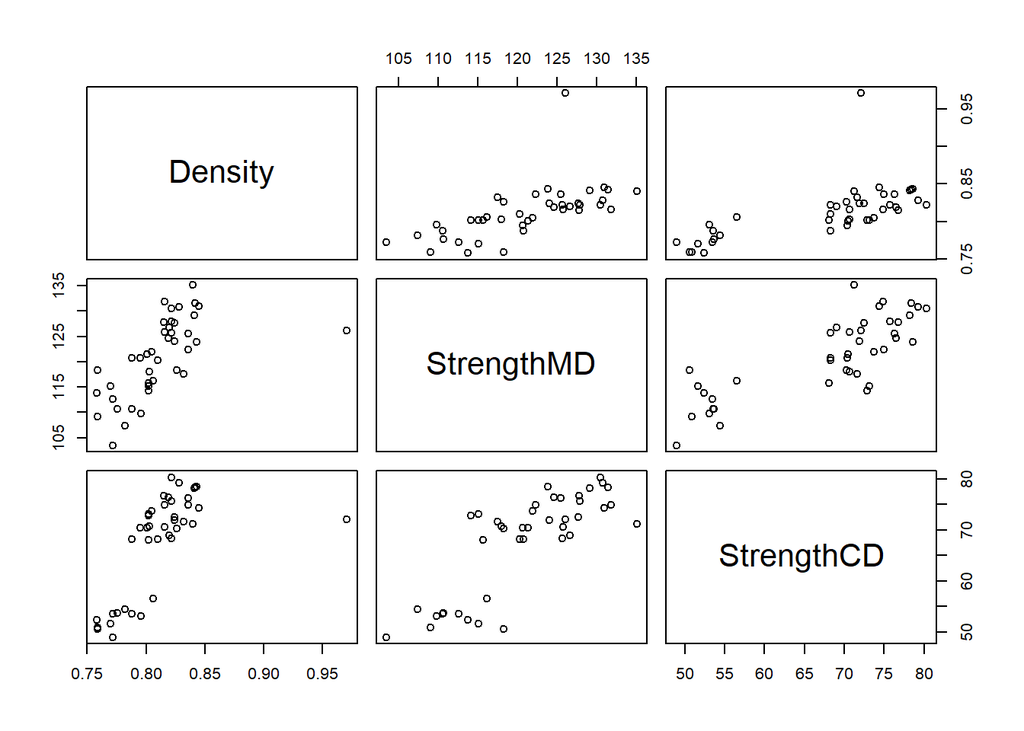

```r
pairs(Paper)
```

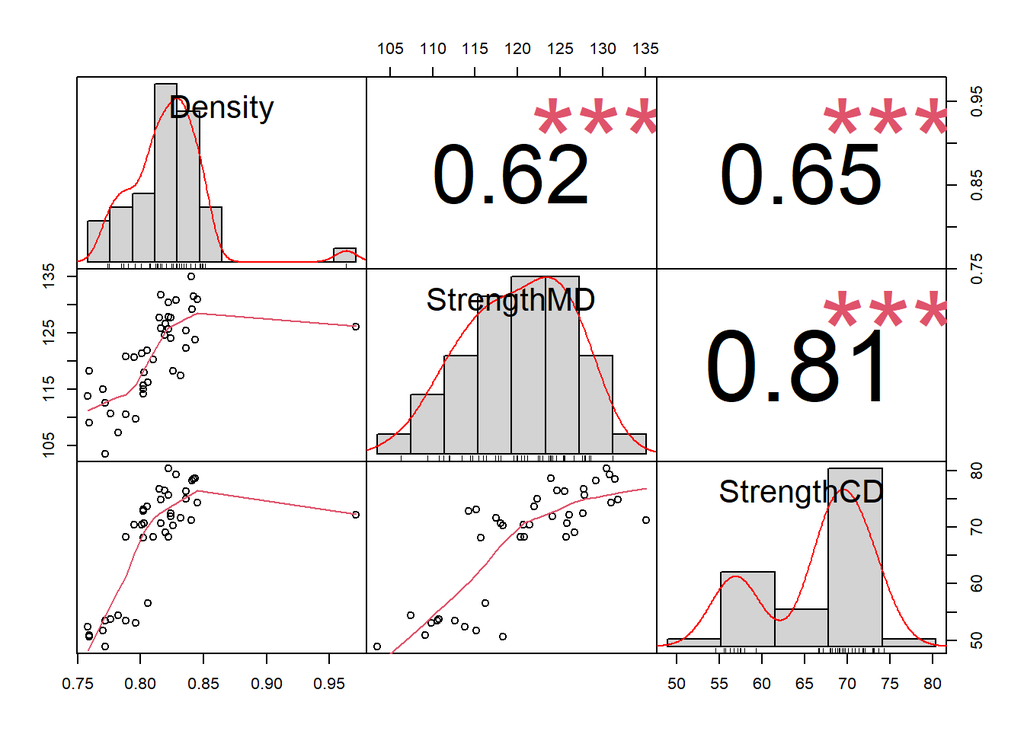

```r
library("PerformanceAnalytics")
chart.Correlation(Paper, histogram = TRUE, pch = 19)
```

From the scatterplot matrix, the outlier problem seems to be more apparent in the scatterplots between Density and StrengthMD and Density and StrengthCD. We check that the outlier is at around 0.97 of Density, which corresponds to the observation no 25.

```r
Paper[25, ]
```

```
   Density StrengthMD StrengthCD
25   0.971      126.1       72.1
```

# Question 5 Anscombe

The datasets in the data.frame `Anscombe` demonstrate both the importance of graphing data before analyzing it and the effect of outliers and other influential observations on statistical properties. (Anscombe, F. J. (1973). “Graphs in Statistical Analysis”. American Statistician. 27 (1): 17–21)

(a). First of all have a look at the data by graphing each of the 4 column pairs (x1,y1) , (x2,y2), (x3,y3) and (x4,y4) in the `Anscombe` dataset. How would you describe each relationship?

[figure not shown]

```r
View(Anscombe)
```

Clearly, we can see there is some sort of a positive relationship between the x and y variables for each dataset. For the top 2 plots we would particularly be asking the question “Is the modelling of a linear relationship appropriate?”. For the bottom 2 plots we would be wondering about the influence of the outliers.

(b). Before confirming by calculation, estimate the Pearson’s correlation coefficient for each pair.

Looking at the above scatterplots, the (Pearson) correlation which is a measure of linear relationship can be estimated as follows:

```
-  x1 and y1 might be a moderate (say r1=0.70);

-  x2 and y2 might be weak (say 0.50) as it is a nonlinear form;

-  x3 and y3 might be strong (say 0.80) with one outlier:

-  x4 and y4 might be very weak (say 0.10) as it is a constant function.
```

(c). Now calculate the (Pearson) correlation between $x$ and $y$ for each dataset. What surprising feature do you notice?

```
          x1        y1
x1 1.0000000 0.8164205
y1 0.8164205 1.0000000
```

```
          x2        y2
x2 1.0000000 0.8162365
y2 0.8162365 1.0000000
```

```
          x3        y3
x3 1.0000000 0.8162867
y3 0.8162867 1.0000000
```

```
          x4        y4
x4 1.0000000 0.8165214
y4 0.8165214 1.0000000
```

Interestingly, the normal measure of correlation between x and y is almost identical for all 4 datasets, despite very different distributions of the variables!

This example demonstrates both the importance of graphing data before analyzing it and the effect of outliers and other influential observations on statistical properties.

(d). Calculate the rank correlation coefficient for each pair. How do you explain any differences?

We calculate the Spearman rank correlations.

```
          x1        y1
x1 1.0000000 0.8181818
y1 0.8181818 1.0000000
```

```
          x2        y2
x2 1.0000000 0.6909091
y2 0.6909091 1.0000000
```

```
          x3        y3
x3 1.0000000 0.9909091
y3 0.9909091 1.0000000
```

```
    x4  y4
x4 1.0 0.5
y4 0.5 1.0
```

OR you can do it this way.

```r
pearson.r <- c(cor(Anscombe$x1, Anscombe$y1), cor(Anscombe$x2, Anscombe$y2), cor(Anscombe$x3,
    Anscombe$y3), cor(Anscombe$x4, Anscombe$y4))
spearman.r <- c(cor(Anscombe$x1, Anscombe$y1, method = "spearman"), cor(Anscombe$x2,
    Anscombe$y2, method = "spearman"), cor(Anscombe$x3, Anscombe$y3, method = "spearman"),
    cor(Anscombe$x4, Anscombe$y4, method = "spearman"))
rbind(pearson.r, spearman.r)
```

```
                [,1]      [,2]      [,3]      [,4]
pearson.r  0.8164205 0.8162365 0.8162867 0.8165214
spearman.r 0.8181818 0.6909091 0.9909091 0.5000000
```

For dataset 1, where the correlation can be reasonably described by a simple linear relationship, both measures of correlation are quite comparable.

In plot 2, the relationship is clearly not linear, although higher values of x are associated with higher values of y. But the relationship is not monotonic so the rank-based measure is less than that of the Pearson coefficient.

Plots 3 and 4 illustrate the influence of outliers. For dataset 3 where most points lie on a perfect line, the Pearson measure is more susceptible to the outlier than the Spearman measure. For dataset 4, the outlying point is a highly influential point (because the x value is far removed from the bulk of the other x values), and the Pearson coefficient is markedly inflated.

[OPTIONAL} Another way to do the above plots and correlations on the plots is as follows.

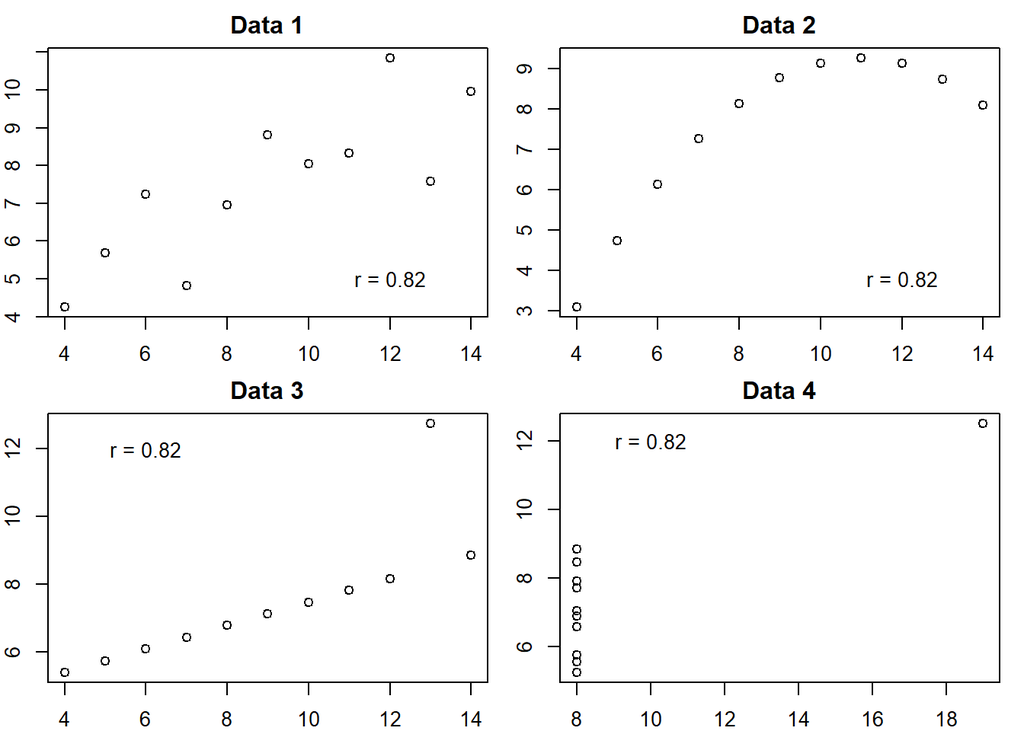

# Reference

JW: Johnson, R. A. and Wichern, D. W. (2007) Applied Multivariate Statistical Analysis. 6th ed. , Upper Saddle River, NJ: Prentice Hall.